# Priors

Ben Bolker

Includes material from Ian Dworkin and Jonathan Dushoff, but they bear no responsibility for the contents.

```r
library(brms)
library(lme4)
library(broom.mixed)
library(tidybayes)
```

## baseline prior choices

See [distribution explorer](https://distribution-explorer.github.io) ([backend](https://github.com/distribution-explorer/distribution-explorer.github.io))

- real-valued parameters: Gaussian (or Student-$t$)
- variances: half-Student-t on the standard deviation scale *or* log-Normal
- other positive-valued: Gamma or log-Normal
  - older: inverse-Gamma for variances, for conjugacy
- bounded: Beta
- correlation/covariance matrices
  - [LKJ](https://distribution-explorer.github.io/multivariate_continuous/lkj.html) or “onion” (Lewandowski, Kurowicka, and Joe 2009). $\eta=1$ $\to$ uniform, $\eta>1$ favours a stronger diagonal (smaller correlations)
  - Wishart [older] (‘mean’ = typical corr matrix, usually diagonal; shape ‘nu’ determines variance [1 is equivalent to an exponential dist for 1-dim, so <1 is ‘weak’]

## independent vs multivariate priors

- we usually set priors on parameters one at a time
- this assumes they’re independent (!)
- hard to do very much about this, but keep it in mind
- means that *reparameterizing* a model (e.g. by centering a variable) can change the priors, if we’re not careful

## prior problems

- scale dependence
- improper priors (scale dependence, identifiability/computational issues)

## issues with proper uniform priors

- Cromwell’s rule (Lindley 1980): don’t exclude *possible* values

## squashing problems

- ‘wide’ on one scale $\neq$ noninformative on a transformed scale
- especially for intervals, e.g. probabilities
- for positive distributions, uninformative *often* leads to a spike at zero (inverse-Gamma)

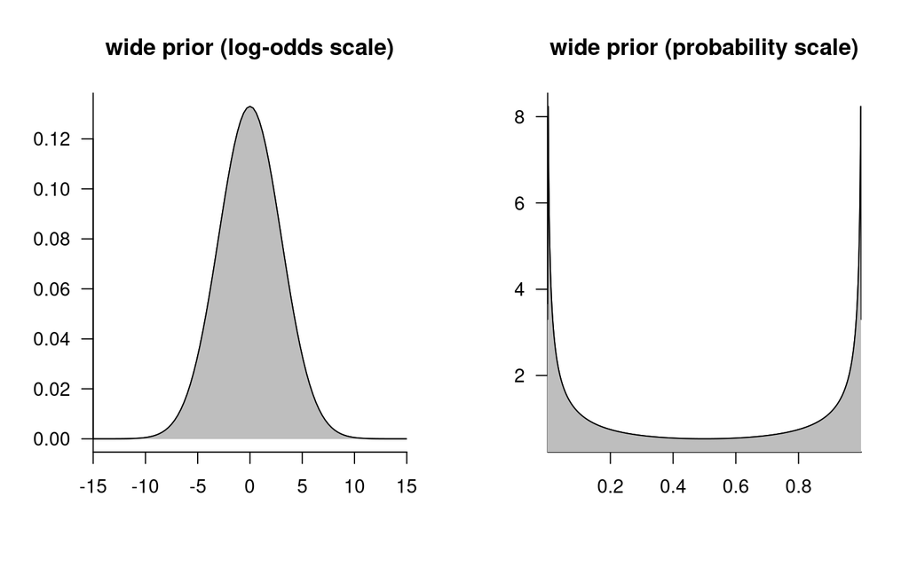

## stacking problems

- when uniform priors that are supposed to be uninformative are actually informative … (Carpenter 2017)
- posterior piles up at the edge

## priors for variances

- people used to use inverse-Gamma a lot (because conjugate): uninformative/wide → big spike at zero (Gelman 2006)
- half-Normal, half-$t$ are better
  - *parameter-expanded priors* in `MCMCglmm` Gelman and Hill (2006)
- regularizing priors (Chung et al. 2013) prevent ‘singularity’
  - singularity doesn’t really matter when fully Bayesian (not MAP!) because we integrate over the whole posterior

## priors for covariance/correlation matrices

- a single correlation is easy (e.g. a Beta distribution)
- multivariate correlation/covariance matrix is hard (Wishart)
- separate priors for (log)-SDs, correlations
  - **LKJ** or “onion” (Lewandowski, Kurowicka, and Joe 2009)

## choosing priors

- Singmann et al. (2023) (“using priors over inherently meaningful units instead of default priors on standardized scales”)
- unitless (log, logit-transformed, standardized) parameters make it easier to choose (Schielzeth 2010)
- choose a ‘wide range’ as e.g. $\pm 2\sigma$ or $\pm 3\sigma$ of a Normal (or $t$) prior: Inchausti (2023), Wan et al. (2014)
- use prior information but dilute it: Ibrahim et al. (2015)

## prior sensitivity

- compare results with different priors: Crome, Thomas, and Moore (1996)
- more general refs: Banner, Irvine, and Rodhouse (2020); ; Edwards (1996); Nicenboim, Schad, and Vasishth (n.d.) (chap 3); Gelman et al. (2020); Xie and Carlin (2006); Kallioinen et al. (2022); Fink (1997); Sarma and Kay (2020)
- **lots** here (kind of a grab bag): https://github.com/stan-dev/stan/wiki/Prior-Choice-Recommendations
- https://www.monicaalexander.com/posts/2020-28-02-bayes_viz/

## definitions (from Banner, Irvine, and Rodhouse (2020))

[output not shown]

## Bayesian workflow

This figure from Gelman et al. (2020) is a little overwhelming. It is more targeted toward people who are developing new Bayesian models from scratch rather than using a platform like `brms` but can still be useful.

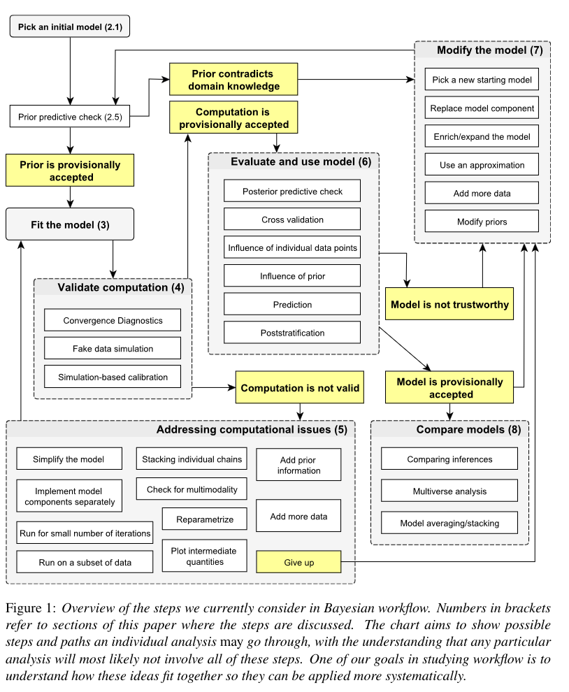

## References

Banner, Katharine M., Kathryn M. Irvine, and Thomas J. Rodhouse. 2020. “The Use of Bayesian Priors in Ecology: The Good, the Bad and the Not Great.” *Methods in Ecology and Evolution* 11 (8): 882–89. https://doi.org/10.1111/2041-210X.13407.

Carpenter, Bob. 2017. “Computational and Statistical Issues with Uniform Interval Priors.” *Statistical Modeling, Causal Inference, and Social Science*. http://andrewgelman.com/2017/11/28/computational-statistical-issues-uniform-interval-priors/.

Chung, Yeojin, Sophia Rabe-Hesketh, Vincent Dorie, Andrew Gelman, and Jingchen Liu. 2013. “A Nondegenerate Penalized Likelihood Estimator for Variance Parameters in Multilevel Models.” *Psychometrika* 78 (4): 685–709. https://doi.org/10.1007/s11336-013-9328-2.

Crome, F. H. J., M. R. Thomas, and L. A. Moore. 1996. “A Novel Bayesian Approach to Assessing Impacts of Rain Forest Logging.” *Ecological Applications* 6: 1104–23.

Edwards, Don. 1996. “Comment: The First Data Analysis Should Be Journalistic.” *Ecological Applications* 6 (4): 1090–94.

Fink, Daniel. 1997. “A Compendium of Conjugate Priors.” https://web.archive.org/web/20090529203101/http://www.people.cornell.edu/pages/df36/CONJINTRnew%20TEX.pdf.

Gelman, Andrew. 2006. “Prior Distributions for Variance Parameters in Hierarchical Models (Comment on Article by Browne and Draper).” *Bayesian Analysis* 1 (3): 515–34. https://doi.org/10.1214/06-BA117A.

Gelman, Andrew, and Jennifer Hill. 2006. *Data Analysis Using Regression and Multilevel/Hierarchical Models*. Cambridge, England: Cambridge University Press.

Gelman, Andrew, Aki Vehtari, Daniel Simpson, Charles C. Margossian, Bob Carpenter, Yuling Yao, Lauren Kennedy, Jonah Gabry, Paul-Christian Bürkner, and Martin Modrák. 2020. “Bayesian Workflow.” *arXiv:2011.01808 [Stat]*, November. http://arxiv.org/abs/2011.01808.

Ibrahim, Joseph G., Ming-Hui Chen, Yeongjin Gwon, and Fang Chen. 2015. “The Power Prior: Theory and Applications.” *Statistics in Medicine* 34 (28): 3724–49. https://doi.org/10.1002/sim.6728.

Inchausti, Pablo. 2023. *Statistical Modeling With R: A Dual Frequentist and Bayesian Approach for Life Scientists*. Oxford University Press.

Kallioinen, Noa, Topi Paananen, Paul-Christian Bürkner, and Aki Vehtari. 2022. “Detecting and Diagnosing Prior and Likelihood Sensitivity with Power-Scaling.” arXiv. https://doi.org/10.48550/arXiv.2107.14054.

Lewandowski, Daniel, Dorota Kurowicka, and Harry Joe. 2009. “Generating Random Correlation Matrices Based on Vines and Extended Onion Method.” *Journal of Multivariate Analysis* 100 (9): 1989–2001. https://doi.org/10.1016/j.jmva.2009.04.008.

Lindley, Dennis V. 1980. “The Bayesian Approach to Statistics.” ORC 80-9. Operations Research Center, University of California, Berkeley. https://apps.dtic.mil/sti/pdfs/ADA087836.pdf.

Nicenboim, Bruno, Daniel Schad, and Shravan Vasishth. n.d. *An Introduction to Bayesian Data Analysis for Cognitive Science*. https://vasishth.github.io/bayescogsci/book/.

Sarma, Abhraneel, and Matthew Kay. 2020. “Prior Setting in Practice: Strategies and Rationales Used in Choosing Prior Distributions for Bayesian Analysis.” In *Proceedings of the 2020 CHI Conference on Human Factors in Computing Systems*, 1–12. CHI ’20. New York, NY, USA: Association for Computing Machinery. https://doi.org/10.1145/3313831.3376377.

Schielzeth, Holger. 2010. “Simple Means to Improve the Interpretability of Regression Coefficients: Interpretation of Regression Coefficients.” *Methods in Ecology and Evolution* 1 (2): 103–13. https://doi.org/10.1111/j.2041-210X.2010.00012.x.

Singmann, Henrik, David Kellen, Gregory E. Cox, Suyog H. Chandramouli, Clintin P. Davis-Stober, John C. Dunn, Quentin F. Gronau, et al. 2023. “Statistics in the Service of Science: Don’t Let the Tail Wag the Dog.” *Computational Brain & Behavior* 6 (1): 64–83. https://doi.org/10.1007/s42113-022-00129-2.

Wan, Xiang, Wenqian Wang, Jiming Liu, and Tiejun Tong. 2014. “Estimating the Sample Mean and Standard Deviation from the Sample Size, Median, Range and/or Interquartile Range.” *BMC Medical Research Methodology* 14 (1): 135. https://doi.org/10.1186/1471-2288-14-135.

Xie, Yang, and Bradley P. Carlin. 2006. “Measures of Bayesian Learning and Identifiability in Hierarchical Models.” *Journal of Statistical Planning and Inference* 136 (10): 3458–77. https://doi.org/10.1016/j.jspi.2005.04.003.

Last updated: 14 March 2024 19:33